# Using `randomForest` in R

Wyclife Agumba Oluoch

2022-05-17 20:21:50

# Model building using `randomForest()` in R

This work was developed following this [blog post](https://www.r-bloggers.com/2021/04/random-forest-in-r/#:~:text=Random%20Forest%20in%20R%2C%20Random,to%20identify%20the%20important%20attributes).

Here I demonstrate how to use `randomForest()` in R to train a model and make prediction over new data. New data here actually has all features that were used in the training dataset. Generally, the two sets should be overlapping in values, though not exactly the same. By this I mean, it does not make sense to train a model then use it to make prediction on dataset with ranges beyond that of the training set.

We will use the in-built iris data for this demonstration. In that case, we use the four continuous variables (**Sepal.Length, Sepal.Width, Petal.Length, Petal.Width**) to predict **Species** of iris flower.

## Loading the data

```r
data <- iris
str(data)
```

```
## 'data.frame':    150 obs. of  5 variables:
##  $ Sepal.Length: num  5.1 4.9 4.7 4.6 5 5.4 4.6 5 4.4 4.9 ...
##  $ Sepal.Width : num  3.5 3 3.2 3.1 3.6 3.9 3.4 3.4 2.9 3.1 ...
##  $ Petal.Length: num  1.4 1.4 1.3 1.5 1.4 1.7 1.4 1.5 1.4 1.5 ...
##  $ Petal.Width : num  0.2 0.2 0.2 0.2 0.2 0.4 0.3 0.2 0.2 0.1 ...
##  $ Species     : Factor w/ 3 levels "setosa","versicolor",..: 1 1 1 1 1 1 1 1 1 1 ...
```

## Partitioning the data

Here we break down the data into two sets with one being used for training the model and the other being used for testing the model performance. Normally training set should be having more data than the test set. But can vary depending on your use case.

```r
set.seed(1985)
ind <- sample(2, nrow(data), replace = T, prob = c(0.7, 0.3))
train <- data[ind == 1,]
test <- data[ind == 2,]
```

## Building the `randomForest()` model

Building the random forest model using the target variable and all the continuous variables in the data-set.

```r
rf <- randomForest(Species ~., data = train, proximity = TRUE)
print(rf)
```

```
##
## Call:
##  randomForest(formula = Species ~ ., data = train, proximity = TRUE)
##                Type of random forest: classification
##                      Number of trees: 500
## No. of variables tried at each split: 2
##
##         OOB estimate of  error rate: 4.42%
## Confusion matrix:
##            setosa versicolor virginica class.error
## setosa         36          0         0  0.00000000
## versicolor      0         32         3  0.08571429
## virginica       0          2        40  0.04761905
```

## Making prediction

Predicting on train data-set.

```r
predict_train <- predict(rf, train)
confusionMatrix(predict_train, train$Species)
```

```
## Confusion Matrix and Statistics
##
##             Reference
## Prediction   setosa versicolor virginica
##   setosa         36          0         0
##   versicolor      0         35         0
##   virginica       0          0        42
##
## Overall Statistics
##
##                Accuracy : 1
##                  95% CI : (0.9679, 1)
##     No Information Rate : 0.3717
##     P-Value [Acc > NIR] : < 2.2e-16
##
##                   Kappa : 1
##
##  Mcnemar's Test P-Value : NA
##
## Statistics by Class:
##
##                      Class: setosa Class: versicolor Class: virginica
## Sensitivity                 1.0000            1.0000           1.0000
## Specificity                 1.0000            1.0000           1.0000
## Pos Pred Value              1.0000            1.0000           1.0000
## Neg Pred Value              1.0000            1.0000           1.0000
## Prevalence                  0.3186            0.3097           0.3717
## Detection Rate              0.3186            0.3097           0.3717
## Detection Prevalence        0.3186            0.3097           0.3717
## Balanced Accuracy           1.0000            1.0000           1.0000
```

Predicting on test data-set

```r
predict_test <- predict(rf, test)
confusionMatrix(predict_test, test$Species)
```

```
## Confusion Matrix and Statistics
##
##             Reference
## Prediction   setosa versicolor virginica
##   setosa         14          0         0
##   versicolor      0         14         0
##   virginica       0          1         8
##
## Overall Statistics
##
##                Accuracy : 0.973
##                  95% CI : (0.8584, 0.9993)
##     No Information Rate : 0.4054
##     P-Value [Acc > NIR] : 1.715e-13
##
##                   Kappa : 0.9585
##
##  Mcnemar's Test P-Value : NA
##
## Statistics by Class:
##
##                      Class: setosa Class: versicolor Class: virginica
## Sensitivity                 1.0000            0.9333           1.0000
## Specificity                 1.0000            1.0000           0.9655
## Pos Pred Value              1.0000            1.0000           0.8889
## Neg Pred Value              1.0000            0.9565           1.0000
## Prevalence                  0.3784            0.4054           0.2162
## Detection Rate              0.3784            0.3784           0.2162
## Detection Prevalence        0.3784            0.3784           0.2432
## Balanced Accuracy           1.0000            0.9667           0.9828
```

## Model performance

Error rate of the model.

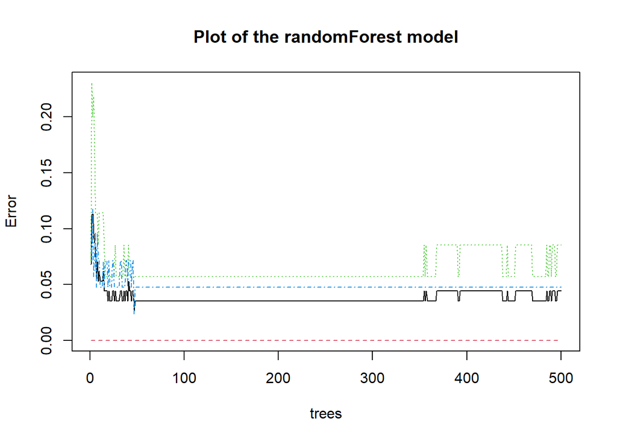

```r
plot(rf, main = "Plot of the randomForest model")
```

## Variable importance

Kind of showing which were the most important variables in predicting species types.

```r
varImp(rf)
```

```
##                Overall
## Sepal.Length  6.595265
## Sepal.Width   2.371027
## Petal.Length 34.452812
## Petal.Width  31.001927
```

So according to this, it seems Petal.Length and Petal.Width are the top two important variables in predicting Species of iris. Let us plot these individually.

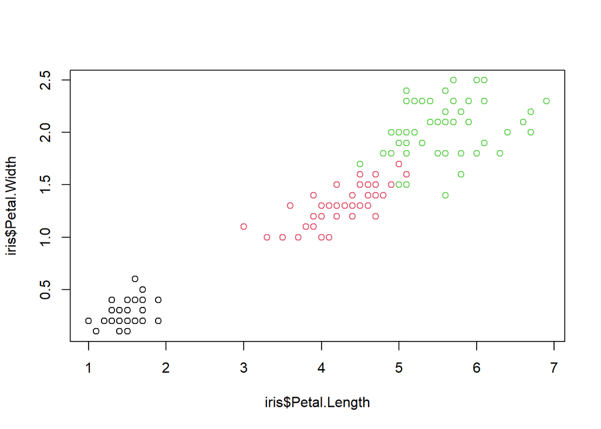

```r
plot(iris$Petal.Length, iris$Petal.Width, col = iris$Species)
```

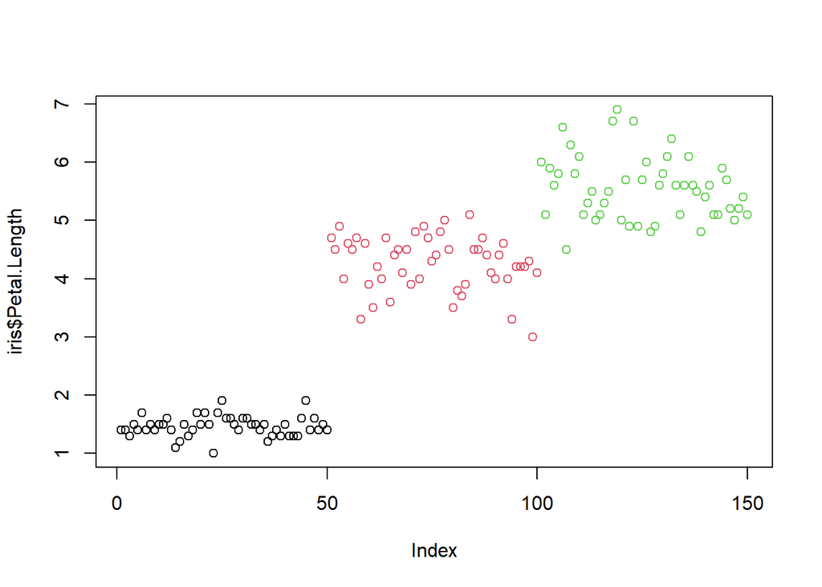

```r
plot(iris$Petal.Length, col = iris$Species)
```

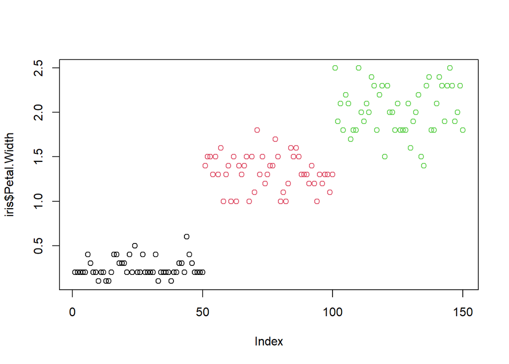

```r
plot(iris$Petal.Width, col = iris$Species)
```

Seems we can see the species grouping themselves distinctively using the two variables.

Tuning the model, although it already performed well.

```
## mtry = 2  OOB error = 6.19%
## Searching left ...
## mtry = 4     OOB error = 3.54%
## 0.4285714 0.05
```

```
## mtry = 8     OOB error = 3.54%
## 0 0.05
## Searching right ...
## mtry = 1     OOB error = 5.31%
## -0.5 0.05
```

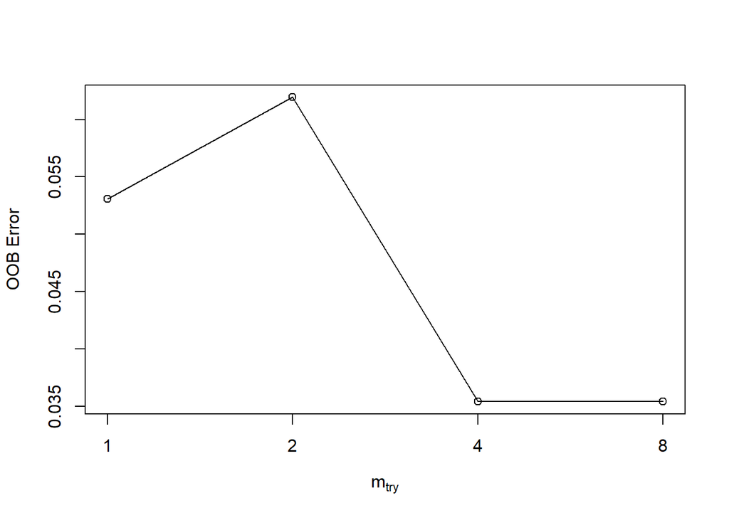

```r
t <- tuneRF(train[, -5], train[, 5],
            stepFactor = 0.5,
            plot = TRUE,
            ntreeTry = 150,
            trace = TRUE,
            improve = 0.05)
```

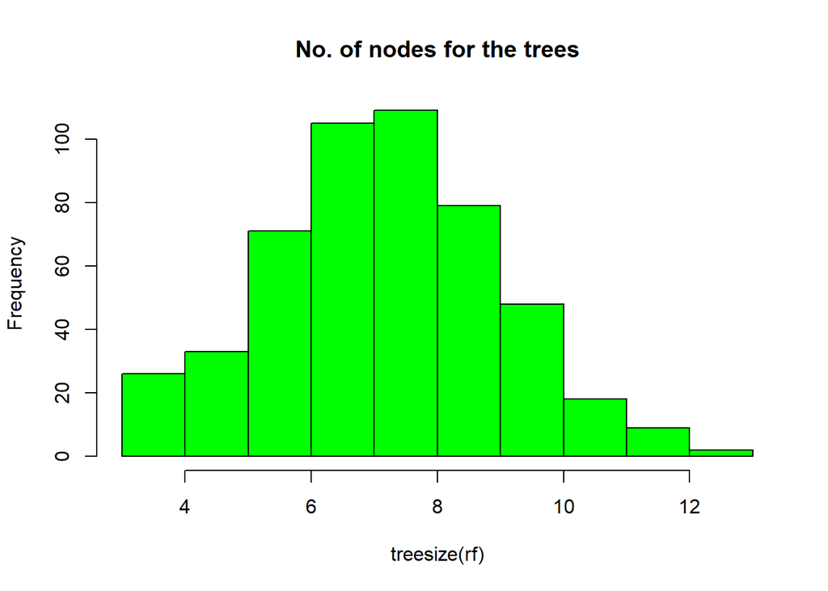

```r
hist(treesize(rf),
     main = 'No. of nodes for the trees',
     col = 'green')
```

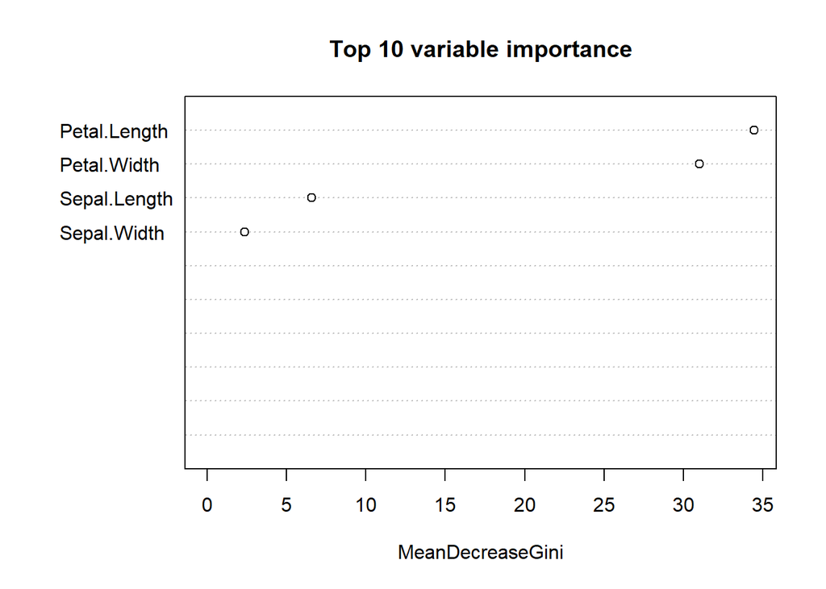

```r
varImpPlot(rf,
           sort = TRUE,
           n.var = 10,
           main = 'Top 10 variable importance')
```

```r
importance(rf)
```

```
##              MeanDecreaseGini
## Sepal.Length         6.595265
## Sepal.Width          2.371027
## Petal.Length        34.452812
## Petal.Width         31.001927
```

Partial dependence plot

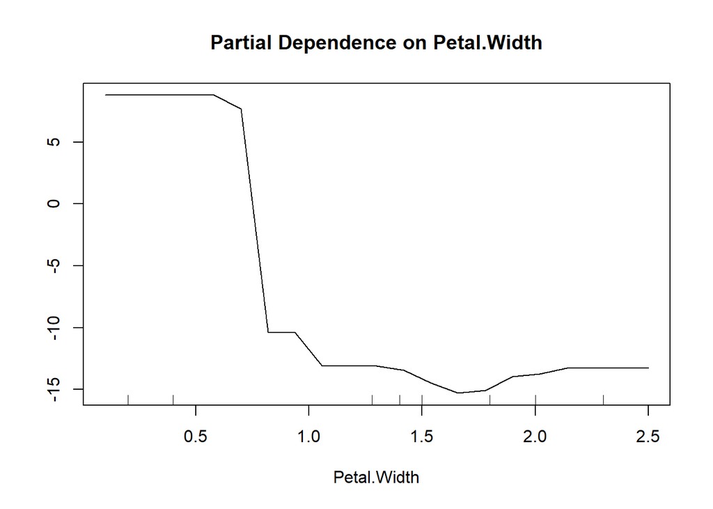

```r
partialPlot(rf, train, Petal.Width, 'setosa')
```

Multi-dimensional plot

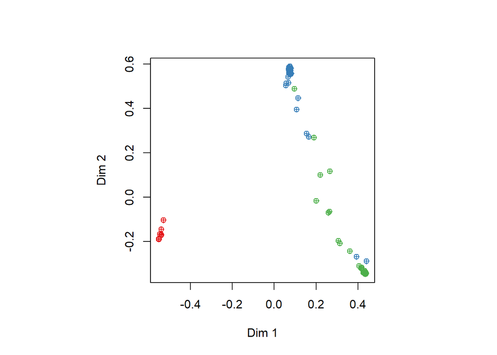

```r
MDSplot(rf, train$Species, pch = 10)
```

Allaire, JJ, Yihui Xie, Jonathan McPherson, Javier Luraschi, Kevin Ushey, Aron Atkins, Hadley Wickham, Joe Cheng, Winston Chang, and Richard Iannone. 2022. *Rmarkdown: Dynamic Documents for r*. https://CRAN.R-project.org/package=rmarkdown.

Breiman, Leo, Adele Cutler, Andy Liaw, and Matthew Wiener. 2022. *randomForest: Breiman and Cutler’s Random Forests for Classification and Regression*. https://www.stat.berkeley.edu/~breiman/RandomForests/.

Kuhn, Max. 2022. *Caret: Classification and Regression Training*. https://github.com/topepo/caret/.

Liaw, Andy, and Matthew Wiener. 2002. “Classification and Regression by randomForest.” *R News* 2 (3): 18–22. https://CRAN.R-project.org/doc/Rnews/.

Qiu, Yixuan. 2021. *Prettydoc: Creating Pretty Documents from r Markdown*. https://github.com/yixuan/prettydoc.

R Core Team. 2022. *R: A Language and Environment for Statistical Computing*. Vienna, Austria: R Foundation for Statistical Computing. https://www.R-project.org/.

Sarkar, Deepayan. 2008. *Lattice: Multivariate Data Visualization with r*. New York: Springer. http://lmdvr.r-forge.r-project.org.

———. 2021. *Lattice: Trellis Graphics for r*. http://lattice.r-forge.r-project.org/.

Wickham, Hadley. 2016. *Ggplot2: Elegant Graphics for Data Analysis*. Springer-Verlag New York. https://ggplot2.tidyverse.org.

Wickham, Hadley, Winston Chang, Lionel Henry, Thomas Lin Pedersen, Kohske Takahashi, Claus Wilke, Kara Woo, Hiroaki Yutani, and Dewey Dunnington. 2022. *Ggplot2: Create Elegant Data Visualisations Using the Grammar of Graphics*. https://CRAN.R-project.org/package=ggplot2.

Xie, Yihui. 2014. “Knitr: A Comprehensive Tool for Reproducible Research in R.” In *Implementing Reproducible Computational Research*, edited by Victoria Stodden, Friedrich Leisch, and Roger D. Peng. Chapman; Hall/CRC. http://www.crcpress.com/product/isbn/9781466561595.

———. 2015. *Dynamic Documents with R and Knitr*. 2nd ed. Boca Raton, Florida: Chapman; Hall/CRC. https://yihui.org/knitr/.

———. 2022. *Knitr: A General-Purpose Package for Dynamic Report Generation in r*. https://yihui.org/knitr/.

Xie, Yihui, J. J. Allaire, and Garrett Grolemund. 2018. *R Markdown: The Definitive Guide*. Boca Raton, Florida: Chapman; Hall/CRC. https://bookdown.org/yihui/rmarkdown.

Xie, Yihui, Christophe Dervieux, and Emily Riederer. 2020. *R Markdown Cookbook*. Boca Raton, Florida: Chapman; Hall/CRC. https://bookdown.org/yihui/rmarkdown-cookbook.